# LLM Refusal Strategy — Descriptive Analysis

## 6.4 Selected hypothesis-shaped views

> *Pre-registered framing direction (paper draft): modern safety training appears to shift LLM refusals toward firmer boundaries and away from human-like face-saving moves. The plots below set up that contrast — they are descriptive only and intentionally avoid significance testing at this stage.*

### Apology decay across OpenAI and Anthropic releases

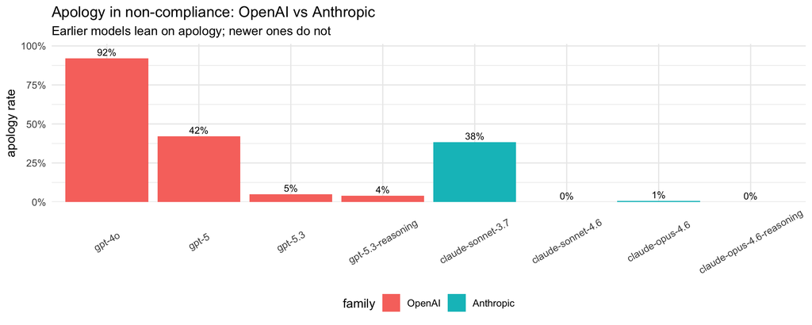

```r
df_balanced_nc |>
  filter(family %in% c("OpenAI", "Anthropic"),
         !is.na(apology)) |>
  group_by(family, model) |>
  summarise(apology_rate = mean(apology), n = n(), .groups = "drop") |>
  ggplot(aes(model, apology_rate, fill = family)) +
    geom_col() +
    geom_text(aes(label = percent(apology_rate, accuracy = 1)), vjust = -0.4, size = 3) +
    scale_y_continuous(labels = percent_format(1), expand = expansion(mult = c(0, 0.1))) +
    labs(x = NULL, y = "apology rate",
         title = "Apology in non-compliance: OpenAI vs Anthropic",
         subtitle = "Earlier models lean on apology; newer ones do not") +
    theme_minimal(base_size = 11) +
    theme(axis.text.x = element_text(angle = 30, vjust=0.5, hjust=0.5),
          legend.position = "bottom")
```

### Negative stance is high almost everywhere

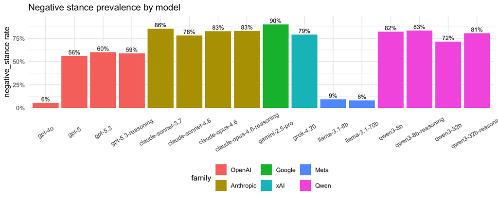

```r
df_balanced_nc |>
  filter(!is.na(negative_stance)) |>
  group_by(family, model) |>
  summarise(rate = mean(negative_stance), .groups = "drop") |>
  ggplot(aes(model, rate, fill = family)) +
    geom_col() +
    geom_text(aes(label = percent(rate, accuracy = 1)), vjust = -0.4, size = 3) +
    scale_y_continuous(labels = percent_format(1), expand = expansion(mult = c(0, 0.1))) +
    labs(x = NULL, y = "negative_stance rate",
         title = "Negative stance prevalence by model") +
    theme_minimal(base_size = 11) +
    theme(axis.text.x = element_text(angle = 30, vjust=0.5, hjust=0.5),
          legend.position = "bottom")
```

### Affiliative features: positive alignment & solidarity

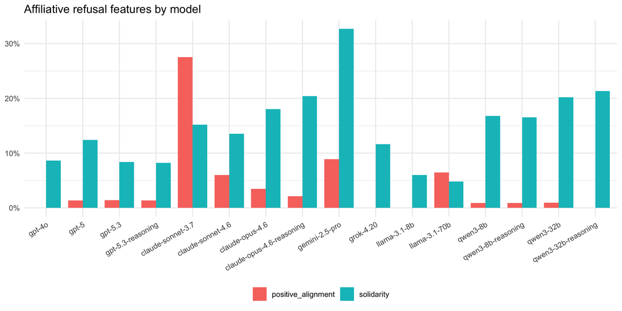

```r
df_balanced_nc |>
  select(family, model, positive_alignment, solidarity) |>
  pivot_longer(c(positive_alignment, solidarity), names_to = "feature", values_to = "value") |>
  filter(!is.na(value)) |>
  group_by(family, model, feature) |>
  summarise(rate = mean(value), .groups = "drop") |>
  ggplot(aes(model, rate, fill = feature)) +
    geom_col(position = position_dodge(width = 0.8), width = 0.8) +
    scale_y_continuous(labels = percent_format(1)) +
    labs(x = NULL, y = NULL, fill = NULL,
         title = "Affiliative refusal features by model") +
    theme_minimal(base_size = 11) +
    theme(axis.text.x = element_text(angle = 30, hjust = 1),
          legend.position = "bottom")
```

# 7. Hard prompts: when one model refuses, what do the others do?

A natural follow-up to the service-level refusal characterisation in §1.2: if Anthropic blocks a prompt at the API level, **how do OpenAI / Google / Meta / Qwen etc handle the same prompt in their own voice?** This section subsets to the prompts that triggered at least one service-level refusal — the hardest end of the corpus — and asks what *other* models did with them.

## 7.1 The hard-prompt subset

```r
HARD_PROMPTS <- df_full |>
  filter(judge_skipped) |>
  pull(final_sample_id) |>
  unique()

df_hard           <- df_full |> filter(final_sample_id %in% HARD_PROMPTS)
df_hard_responses <- df_hard |> filter(!judge_skipped, !parse_error, !is.na(layer0))

# Per-family SLR contribution: how many distinct prompts did each family block?
slr_contrib <- df_full |>
  filter(judge_skipped) |>
  group_by(family) |>
  summarise(n_slr = n(),
            n_distinct_prompts = n_distinct(final_sample_id),
            .groups = "drop")

slr_contrib |>
  kable(caption = paste0("Per-family contribution to the ", length(HARD_PROMPTS),
                         "-prompt hard subset. A prompt counts toward a family if at least one of its models triggered a service-level refusal on it.")) |>
  kable_styling(bootstrap_options = c("striped","hover"), full_width = FALSE)
```

Per-family contribution to the 33-prompt hard subset. A prompt counts toward a family if at least one of its models triggered a service-level refusal on it.

| family | n_slr | n_distinct_prompts |
| --- | --- | --- |
| OpenAI | 1 | 1 |
| Anthropic | 19 | 8 |
| Google | 19 | 19 |
| xAI | 19 | 19 |

## 7.2 L0 distribution on hard prompts, by responding family

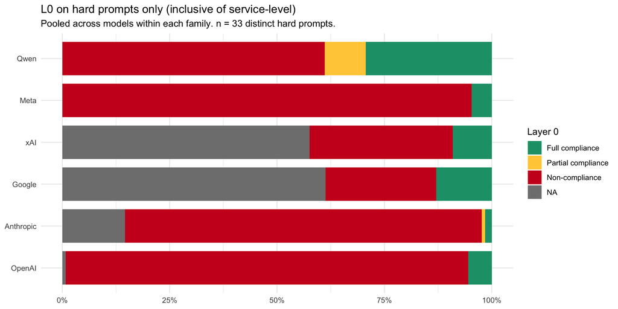

```r
df_hard |>
  mutate(layer0_view = case_when(
    judge_skipped               ~ "Service-Level",
    is.na(layer0)               ~ NA_character_,
    TRUE                         ~ layer0
  )) |>
  filter(!is.na(layer0_view)) |>
  count(family, layer0_view) |>
  group_by(family) |>
  mutate(prop = n / sum(n),
         layer0_view = factor(layer0_view, levels = l0_levels_incl)) |>
  ungroup() |>
  ggplot(aes(family, prop, fill = layer0_view)) +
    geom_col(width = 0.8) +
    scale_y_continuous(labels = percent_format(1)) +
    scale_fill_manual(values = l0_pal_incl) +
    coord_flip() +
    labs(x = NULL, y = NULL, fill = "Layer 0",
         title = "L0 on hard prompts only (inclusive of service-level)",
         subtitle = paste0("Pooled across models within each family. n = ",
                           length(HARD_PROMPTS), " distinct hard prompts.")) +
    theme_minimal(base_size = 11)
```